# Βήμα 4: Alignment to reference genome

Σε αυτό το στάδιο θα χαρτογραφήσουμε τις αλληλουχίες που έχουν καταγραφεί στα αρχεία FASTQ μας σε ένα γονιδίωμα αναφοράς. Θα προσπαθήσουμε, δηλαδή, να εντοπίσουμε από ποιο τμήμα του γονιδιώματος προέρχονται οι αλληλουχίες. Για την χαρτογράφηση θα χρησιμοποιήσουμε το εργαλείο BWA.

Στο αρχείο `Snakefile` προσθέτουμε τον κανόνα:

```python
rule bwa_map:
    input:
        "reference/genome.fa",
        "trimmed_reads/{sample}_trim.fastq"
    output:
        "mapped_reads/{sample}.bam"
    shell:
        "bwa mem {input} | samtools view -Sb - > {output}"
```

Τώρα μπορούμε να εκτελέσουμε τη ροή εργασίας μας με την εντολή:

```bash
snakemake --cores 1 mapped_reads/A.bam mapped_reads/B.bam
```

## Αρχεία SAM/BAM

Το αρχείο SAM είναι ένα αρχείο κειμένου που περιέχει πληροφορίες για κάθε ανάγνωση και την θέση της στο γονιδίωμα. Η συμπιεσμένη μορφή του αρχείου SAM είναι το αρχείο BAM. Χρησιμοποιούμε αυτή τη μορφή γιατί είναι πιο αποδοτική στην αποθήκευση των δεδομένων.

Το αρχείο αρχίζει με μία κεφαλίδα (header), η οποία είναι προαιρετική. Το header χρησιμοποιείται για να περιγράψει την προέλευση των δεδομένων, το γονιδίωμα αναφοράς, τη μέθοδο χαρτογράφησης κ.λπ. Το ακριβές περιεχόμενο διαφέρει ανάλογα με το λογισμικό που χρησιμοποιείται.

Κάθε γραμμή που ακολουθεί αντιστοιχεί στα δεδομένα χαρτογράφησης για κάθε read. Κάθε γραμμή έχει 11 υποχρεωτικά πεδία για τις βασικές πληροφορίες χαρτογράφησης και ένα μεταβλητό αριθμό άλλων πεδίων για πληροφορίες που είναι ειδικές για κάθε λογισμικό. Ένα παράδειγμα από ένα αρχείο SAM παρουσιάζεται παρακάτω με τα διάφορα πεδία επισημασμένα.

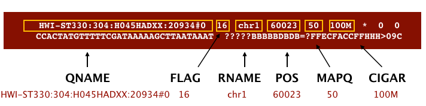

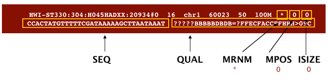

## Sort BAM file by coordinates

Τα reads εντός των αρχείων BAM πρέπει να είναι ταξινομημένα (sorted) σύμφωνα με τις συντεταγμένες τους πριν μπορέσουν να χρησιμοποιηθούν από πολλά εργαλεία.

Τα αρχεία SAM/BAM μπορούν να είναι ταξινομημένα με βάση τις συντεταγμένες στο γονιδίωμα αναφοράς ή με βάση το όνομα του read ή με άλλους τρόπους. Κάθε εργαλείο σε κατάντι αναλύσεις μπορεί να απαιτεί διαφορετική ταξινόμηση.

Για να ταξινομήσουμε τα αρχεία BAM μας, προσθέτουμε έναν νέο κανόνα στο Snakefile:

```python
rule samtools_sort:
    input:
        "mapped_reads/{sample}.bam"
    output:
        "sorted_reads/{sample}.bam"
    shell:
        "samtools sort -T sorted_reads/{wildcards.sample} "
        "-O bam {input} > {output}"
```

Επιπλέον Θα προσθέσουμε και ένα indexing κανόνα για τα συμπιεσμένα αρχεία BAM, ώστε αυτά να είναι εύκολα προσπελάσιμα:

```python
rule samtools_index:
    input:
        "sorted_reads/{sample}.bam"
    output:
        "sorted_reads/{sample}.bam.bai"
    shell:
        "samtools index {input}"
```

Μπορούμε να οπτικοποιήσουμε ξανά τη ροή εργασίας μας με την εντολή:

```bash
snakemake --dag sorted_reads/{A,B}.bam.bai | dot -Tsvg > dag.svg
```

Τώρα μπορούμε να εκτελέσουμε τη ροή εργασίας μας με την εντολή:

```bash
snakemake --cores 1 sorted_reads/A.bam.bai sorted_reads/B.bam.bai
```

# Βήμα 5: Variant calling

Η καταγραφή πολυμορφισμών (variant calling) είναι το στάδιο της ανάλυσης δεδομένων που αφορά την εντοπισμό των διαφορών στην αλληλουχία μεταξύ του ατόμου που εξετάζεται και του γονιδιώματος αναφοράς. Οι διαφορές αυτές μπορεί να είναι μονονουκλεοτιδικές (Single Nucleotide Variants, SNVs), προσθήκες ή διαγραφές βάσεων (insertions or deletions, indels) ή μεγαλύτερες μεταβολές στην αλληλουχία.

Κάθε πολυμορφισμός συνοδεύεται από μία εκτίμηση της συχνότητάς του και μία μέτρηση της βεβαιότητας καταγραφής. Όπως και στα προηγούμενα στάδια της ανάλυσης, υπάρχουν πολλά εργαλεία διαθέσιμα για την καταγραφή πολυμορφισμών. Σε αυτή την άσκηση θα χρησιμοποιήσουμε το bcftools.

Στο Snakefile, προσθέτουμε τον κανόνα:

```python
rule bcftools_call:
    input:
        fa="reference/genome.fa",
        bam=expand("sorted_reads/{sample}.bam", sample=SAMPLES),
        bai=expand("sorted_reads/{sample}.bam.bai", sample=SAMPLES)
    output:
        "calls/all.vcf"
    shell:
        "bcftools mpileup -f {input.fa} {input.bam} | "
        "bcftools call -mv - > {output}"
```

Στην πρώτη γραμμή η εντολή `bcftools mpileup` υπολογίζει το βάθος ανάγνωσης (read depth - read coverage) για κάθε θέση του γονιδιώματος αναφοράς. Η εντολή `bcftools call` χρησιμοποιεί τα αποτελέσματα του `mpileup` για να καταγράψει τους πολυμορφισμούς.

Τώρα μπορούμε να οπτικοποιήσουμε ξανά τη ροή εργασίας μας με την εντολή:

```bash
snakemake --dag calls/all.vcf | dot -Tsvg > dag.svg
```

Ποιους κανόνες περιλαμβάνει η ροή εργασίας;  
Ποιοι κανόνες θα εκτελεστούν;  
Με ποιο τρόπο προσδιορίζει το snakemake τις εξαρτήσεις για ένα κανόνα;

## Προσθήκη target rule

Μέχρι στιγμής, εκτελούσαμε πάντα τη ροή εργασίας καθορίζοντας ένα αρχείο-στόχο στη γραμμή εντολών. Εκτός από τα ονόματα αρχείων, το Snakemake δέχεται επίσης ονόματα κανόνων ως στόχους, εάν ο ζητούμενος κανόνας δεν έχει wildcards. Ως εκ τούτου, είναι δυνατή η συγγραφή κανόνων-στόχων που συλλέγουν συγκεκριμένα υποσύνολα των επιθυμητών αποτελεσμάτων ή όλα τα αποτελέσματα. Επιπλέον, εάν δεν δοθεί στόχος στη γραμμή εντολών, το Snakemake θα ορίσει τον πρώτο κανόνα του Snakefile ως στόχο.

Ως εκ τούτου, η καλύτερη πρακτική είναι να υπάρχει ένας κανόνας `all` στην κορυφή της ροής εργασίας, ο οποίος έχει όλα τα τυπικά επιθυμητά αρχεία-στόχους ως inputs.

O κανόνας `all` δε χρειάζεται να διαθέτει `output`, ούτε εντολή `shell`.

## Άσκηση

Ποια `input` πρέπει να περιλαμβάνει ο κανόνας `all` ώστε να εκτελεστούν όλοι οι εργασίες που έχουμε συντάξει;